# Matrices1

```python
import numpy as np
import matplotlib.pyplot as plt

# for null spaces
import scipy.linalg

# a pretty-looking matrix from scipy
from scipy.linalg import toeplitz
```

```python
v = np.array([[1,2,3]]).T # col vector
w = np.array([[10,20]])   # row vector
v + w
```

```
array([[11, 21],
       [12, 22],
       [13, 23]])
```

# Visualizing matrices as images

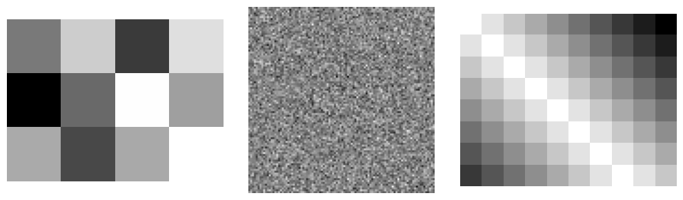

```python
# create some matrices
A = np.random.randn(3,4)
B = np.random.randn(100,100)
C = -toeplitz(np.arange(8),np.arange(10))


# and show them as images
fig,axs = plt.subplots(1,3,figsize=(10,3))

axs[0].imshow(A,cmap='gray')
axs[1].imshow(B,cmap='gray')
axs[2].imshow(C,cmap='gray')

for i in range(3): axs[i].axis('off')
plt.tight_layout()
plt.savefig('Figure_05_01.png',dpi=300)
plt.show()
```

## Rank of a Matrix - its applications

# Slicing out rows and columns

```python
# create a matrix
A = np.reshape(np.arange(1,10),(3,3))
print(A)
```

```
[[1 2 3]
 [4 5 6]
 [7 8 9]]
```

```python
# get the n-th row

print( A[1,:] )

# note that to extract only one row, you don't need the column indices.
print( A[1] )
# But that's potentially confusing, so I recommend avoiding that notation.
```

```
[4 5 6]
[4 5 6]
```

```python
# get the n-th column
print( A[:,1] )
# Note that it prints out as a "row" even thought it's a column of the matrix
```

```
[2 5 8]
```

```python
# multiple rows
A[0:2,:]
```

```
array([[1, 2, 3],
       [4, 5, 6]])
```

```python
# multiple columns
A[:,1:]
```

```
array([[2, 3],
       [5, 6],
       [8, 9]])
```

```python
## extracting a submatrix (multiple rows and cols)

# The goal here is to extract a submatrix from matrix A. Here's A:
# [[1 2 3]
#  [4 5 6]
#  [7 8 9]]

# And we want rows 0-1 and columns 0-1, thus:
# [[1 2]
#  [4 5]]


# seems like this should work...
print( A[0:2,1:2] )
print(' ')

# but this does (remember x:y:z slices from x to y-1 in steps of z)
print( A[0:2:1,0:2:1] )
```

```
[[2]
 [5]]

[[1 2]
 [4 5]]
```

### Matrices and Sub-matrices

```python
# the full matrix
A = np.arange(60).reshape(6,10)

# a block of it
sub = A[1:4:1,0:5:1]


# print them out
print('Original matrix:\n')
print(A)

print('\n\nSubmatrix:\n')
print(sub)
```

```
Original matrix:

[[ 0  1  2  3  4  5  6  7  8  9]
 [10 11 12 13 14 15 16 17 18 19]
 [20 21 22 23 24 25 26 27 28 29]
 [30 31 32 33 34 35 36 37 38 39]
 [40 41 42 43 44 45 46 47 48 49]
 [50 51 52 53 54 55 56 57 58 59]]


Submatrix:

[[10 11 12 13 14]
 [20 21 22 23 24]
 [30 31 32 33 34]]
```

# Some special matrices

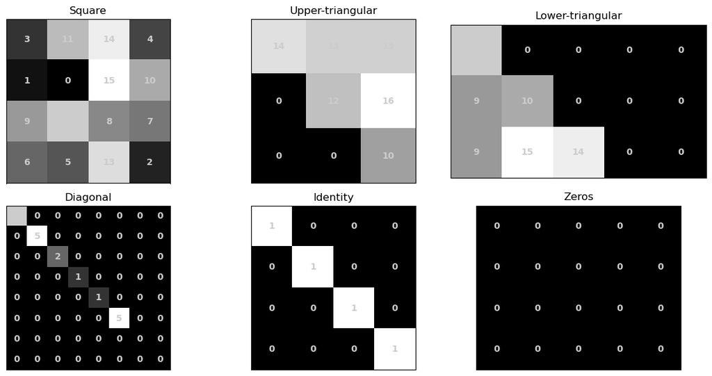

```python
## create some matrices

# square
M1 = np.random.permutation(16).reshape(4,4)

# upper-triangular square
M2 = np.triu(np.random.randint(10,20,(3,3)))

# lower-triangular rectangular
M3 = np.tril(np.random.randint(8,16,(3,5)))

# diagonal
M4 = np.diag( np.random.randint(0,6,size=8) )

# identity
M5 = np.eye(4,dtype=int)

# zeros
M6 = np.zeros((4,5),dtype=int)

matrices  = [ M1,M2,M3,M4,M5,M6 ]
matLabels = [ 'Square','Upper-triangular','Lower-triangular','Diagonal','Identity','Zeros'  ]


_,axs = plt.subplots(2,3,figsize=(12,6))
axs = axs.flatten()

for mi,M in enumerate(matrices):
  axs[mi].imshow(M,cmap='gray',origin='upper',
                 vmin=np.min(M),vmax=np.max(M))
  axs[mi].set(xticks=[],yticks=[])
  axs[mi].set_title(matLabels[mi])

  # text labels
  for (j,i),num in np.ndenumerate(M):
    axs[mi].text(i,j,num,color=[.8,.8,.8],ha='center',va='center',fontweight='bold')



plt.savefig('Figure_05_02.png',dpi=300)
plt.tight_layout()
plt.show()
```

# Some more details about special matrices

```python
# matrix size parameters (called 'shape' in Python lingo)
Mrows = 4 # shape 0
Ncols = 6 # shape 1

# create the matrix!
A = np.random.randn(Mrows,Ncols)

# print out the matrix (rounding to facilitate visual inspection)
np.round(A,3)
```

```
array([[ 1.131, -1.117, -0.367,  0.694, -0.856, -0.008],
       [ 0.265, -0.563, -0.058, -0.738, -0.114,  0.957],
       [ 1.042,  1.146,  0.547, -0.557, -0.588, -0.248],
       [-0.317, -0.489, -1.418,  0.291,  1.808, -0.363]])
```

```python
# Extract the triangular part of a dense matrix

M = 4
N = 6
A = np.random.randn(M,N)

# upper triangular
print('Upper triangular:\n')
print(np.triu(A))

# lower triangular
print('\n\nLower triangular:\n')
print(np.tril(A))
```

```
Upper triangular:

[[-0.34898111 -0.07254531 -0.45786881  0.80490257  1.43556307 -0.52782555]
 [ 0.         -1.53091397  1.55721057  0.64609447 -2.08557435 -2.61086513]
 [ 0.          0.         -0.90201111  0.52998493  0.18339318  1.44024648]
 [ 0.          0.          0.         -0.36604254 -1.04068153  0.3219646 ]]


Lower triangular:

[[-0.34898111  0.          0.          0.          0.          0.        ]
 [-0.49069855 -1.53091397  0.          0.          0.          0.        ]
 [-0.04840871 -0.21163321 -0.90201111  0.          0.          0.        ]
 [ 0.19567487 -0.85143516  0.12387929 -0.36604254  0.          0.        ]]
```

```python
# Diagonal

# input a matrix to get the diagonal elements
A = np.random.randn(5,5)
d = np.diag(A)
print('Input a matrix:\n',d)

# OR input a vector to create a diagonal matrix!
v = np.arange(1,6)
D = np.diag(v)
print('\n\nInput a vector:\n',D)
```

```
Input a matrix:
 [-1.53387228 -0.84053191 -1.21442786 -0.80760146 -0.86115717]


Input a vector:
 [[1 0 0 0 0]
 [0 2 0 0 0]
 [0 0 3 0 0]
 [0 0 0 4 0]
 [0 0 0 0 5]]
```

```python
# Identity and zeros matrices

# Note that you only specify one input
n = 4
I = np.eye(n)
print(f'The {n}x{n} identity matrix:\n',I)
```

```
The 4x4 identity matrix:
 [[1. 0. 0. 0.]
 [0. 1. 0. 0.]
 [0. 0. 1. 0.]
 [0. 0. 0. 1.]]
```

```python
# Zeros matrix

# Important: All shape parameters are given as one input (a tuple or list),
#            unlike np.random.randn()
n = 4
m = 5
I = np.zeros((n,m))
print(f'The {n}x{m} zeros matrix:\n',I)
```

```
The 4x5 zeros matrix:
 [[0. 0. 0. 0. 0.]
 [0. 0. 0. 0. 0.]
 [0. 0. 0. 0. 0.]
 [0. 0. 0. 0. 0.]]
```

# Matrix addition

```python
A = np.array([  [2,3,4],
                [1,2,4] ])

B = np.array([  [ 0, 3,1],
                [-1,-4,2] ])

print(A+B)
```

```
[[ 2  6  5]
 [ 0 -2  6]]
```

# Shifting a matrix

```python
# Not shifting; broadcasting scalar addition
3 + np.eye(2)
```

```
array([[4., 3.],
       [3., 4.]])
```

```python
# This is shifting:

# the matrix
A = np.array([ [4,5, 1],
               [0,1,11],
               [4,9, 7]  ])

# the scalar
s = 6

print('Original matrix:')
print(A), print(' ')

# as in the previous cell, this is broadcasting addition, not shifting
print('Broadcasting addition:')
print(A + s), print(' ')

# This is shifting
print('Shifting:')
print( A + s*np.eye(len(A)) )
```

```
Original matrix:
[[ 4  5  1]
 [ 0  1 11]
 [ 4  9  7]]

Broadcasting addition:
[[10 11  7]
 [ 6  7 17]
 [10 15 13]]

Shifting:
[[10.  5.  1.]
 [ 0.  7. 11.]
 [ 4.  9. 13.]]
```

# Scalar multiplication

```python
print(A), print(' ')
print(s*A)
```

```
[[ 4  5  1]
 [ 0  1 11]
 [ 4  9  7]]

[[24 30  6]
 [ 0  6 66]
 [24 54 42]]
```

# "Standard" matrix multiplication

```python
# Create a few matrices
A = np.random.randn(3,6)
B = np.random.randn(6,4)
C = np.random.randn(6,4)

# try some multiplications, and print out the shape of the product matrix
print( (A@B).shape )
print( np.dot(A,B).shape ) # same as above
print( (B@C).shape )
print( (A@C).shape )
```

```
(3, 4)
(3, 4)
```

[output not shown]

```python
# Note/reminder:

# This is Hadamard (element-wise) multiplication:
print( np.multiply(B,C) ), print(' ')

# This is matrix multiplication
print( np.dot(B,C.T) )

# demonstration:
# np.dot(B,C.T)-B@C.T
```

```
[[ 2.71474897 -0.15815726  0.02161872  0.01706869]
 [-0.8053075   0.0588068   0.16702544  0.00602223]
 [ 0.84421927  2.45490637  0.10144134  0.38982546]
 [-0.25134074  1.80661932  0.48944763 -1.05318606]
 [ 0.19963564  0.92701156 -0.08018005 -0.10997454]
 [ 1.42140014 -0.03324946 -0.76865063 -0.1029376 ]]

[[ 2.59527913  1.57253586 -1.66518613 -0.11938558 -4.10607641  4.38398591]
 [-0.66321524 -0.57345302  2.29795265  0.91136429  2.66463478 -2.36556291]
 [ 0.44600928  0.03115537  3.79039243  1.15459108  2.90901089 -1.83198257]
 [-0.94911059 -1.19117583  5.26602928  0.99154015  3.37672675 -2.60652953]
 [ 0.80408783  0.28324085  1.4675552   1.60492037  0.93649261 -0.5633695 ]
 [ 0.15462526 -0.06678939 -1.53686633  1.36098829 -1.31987932  0.51656245]]
```

# Geometry of matrix-vector multiplication

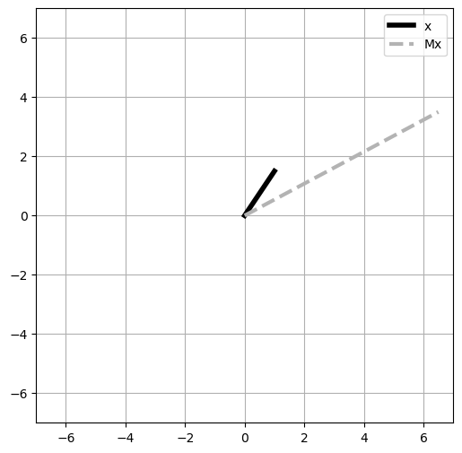

```python
# some matrix
M  = np.array([ [2,3],[2,1] ])
x  = np.array([ [1,1.5] ]).T # transposed into a column vector!
Mx = M@x


plt.figure(figsize=(6,6))

plt.plot([0,x[0,0]],[0,x[1,0]],'k',linewidth=4,label='x')
plt.plot([0,Mx[0,0]],[0,Mx[1,0]],'--',linewidth=3,color=[.7,.7,.7],label='Mx')
plt.xlim([-7,7])
plt.ylim([-7,7])
plt.legend()
plt.grid()
plt.savefig('Figure_05_05a.png',dpi=300)
plt.show()
```

```python
# some matrix
M  = np.array([ [2,3],[2,1] ])
v  = np.array([ [1.5,1] ]).T # transposed into a column vector!
Mv = M@v


plt.figure(figsize=(6,6))

plt.plot([0,v[0,0]],[0,v[1,0]],'k',linewidth=4,label='v')
plt.plot([0,Mv[0,0]],[0,Mv[1,0]],'--',linewidth=3,color=[.7,.7,.7],label='Mv')
plt.xlim([-7,7])
plt.ylim([-7,7])
plt.legend()
plt.grid()
plt.savefig('Figure_05_05b.png',dpi=300)
plt.show()
```

[figure not shown]

# Transpose

```python
# A matrix to transpose
A = np.array([ [3,4,5],[1,2,3] ])

A_T1 = A.T # as method
A_T2 = np.transpose(A) # as function

# double-transpose
A_TT = A_T1.T


# print them
print( A_T1 ), print(' ')
print( A_T2 ), print(' ')
print( A_TT )
```

```
[[3 1]
 [4 2]
 [5 3]]

[[3 1]
 [4 2]
 [5 3]]

[[3 4 5]
 [1 2 3]]
```

# Exercise 1

Create a 3 × 4 matrix using np.arange(12).reshape(3,4). Then write Python code to extract the element in the second row, fourth column

```python
# indexing

A = np.arange(12).reshape(3,4)
print(A)

# find the element in the 2nd row, 4th column
ri = 1
ci = 3

print(f'The matrix element at index ({ri+1},{ci+1}) is {A[ri,ci]}')
```

```
[[ 0  1  2  3]
 [ 4  5  6  7]
 [ 8  9 10 11]]
The matrix element at index (2,4) is 7
```

# Exercise 2

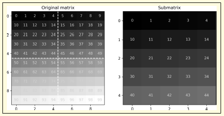

```
[[ 0  1  2  3  4  5  6  7  8  9]
 [10 11 12 13 14 15 16 17 18 19]
 [20 21 22 23 24 25 26 27 28 29]
 [30 31 32 33 34 35 36 37 38 39]
 [40 41 42 43 44 45 46 47 48 49]
 [50 51 52 53 54 55 56 57 58 59]
 [60 61 62 63 64 65 66 67 68 69]
 [70 71 72 73 74 75 76 77 78 79]
 [80 81 82 83 84 85 86 87 88 89]
 [90 91 92 93 94 95 96 97 98 99]]

[[ 0  1  2  3  4]
 [10 11 12 13 14]
 [20 21 22 23 24]
 [30 31 32 33 34]
 [40 41 42 43 44]]
```

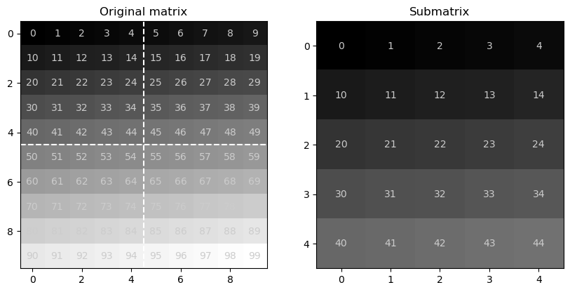

```python
# Create the matrix
C = np.arange(100).reshape((10,10))

# extract submatrix
C_1 = C[0:5:1,0:5:1]

# here's what the matrices look like
print(C), print(' ')
print(C_1)

# visualize the matrices as maps
_,axs = plt.subplots(1,2,figsize=(10,5))

axs[0].imshow(C,cmap='gray',origin='upper',vmin=0,vmax=np.max(C))
axs[0].plot([4.5,4.5],[-.5,9.5],'w--')
axs[0].plot([-.5,9.5],[4.5,4.5],'w--')
axs[0].set_title('Original matrix')
# text labels
for (j,i),num in np.ndenumerate(C):
  axs[0].text(i,j,num,color=[.8,.8,.8],ha='center',va='center')


axs[1].imshow(C_1,cmap='gray',origin='upper',vmin=0,vmax=np.max(C))
axs[1].set_title('Submatrix')
# text labels
for (j,i),num in np.ndenumerate(C_1):
  axs[1].text(i,j,num,color=[.8,.8,.8],ha='center',va='center')


plt.savefig('Figure_05_06.png',dpi=300)
plt.show()
```

# Exercise 3

Diagonal matrices have many interesting properties that make them useful to work with. In this exercise, you will learn about two of those properties: • Premultiplying by a diagonal matrix scales the rows of the right matrix by the corresponding diagonal elements. • Postmultiplying by a diagonal matrix scales the columns of the left matrix by the corresponding diagonal elements. This fact is used in several applications, including computing correlation matrices (Chapter 7) and diagonalizing a matrix (Chapters 13 and 14). Let’s explore an implication of this property. Start by creating three 4 × 4 matrices: a matrix of all ones (hint: np.ones()); a diagonal matrix where the diagonal elements are 1, 4, 9, and 16; and a diagonal matrix equal to the square root of the previous diagonal matrix. Next, print out the pre- and postmultiplied ones matrix by the first diagonal matrix

```python
n = 4

# create "base" matrices
O = np.ones((n,n))
D = np.diag(np.arange(1,n+1)**2)
S = np.sqrt(D)

# pre- and post-multiply
pre = D@O
pst = O@D

# and both
both = S@O@S



# print out the "base" matrices
print('Ones matrix:')
print(O), print(' ')

print('Diagonal matrix:')
print(D), print(' ')

print('Sqrt-diagonal matrix:')
print(S), print(' ')



print('Pre-multiply by diagonal:')
print(pre), print(' ')

print('Post-multiply by diagonal:')
print(pst), print(' ')

print('Pre- and post-multiply by sqrt-diagonal:')
print(both)
```

```
Ones matrix:
[[1. 1. 1. 1.]
 [1. 1. 1. 1.]
 [1. 1. 1. 1.]
 [1. 1. 1. 1.]]

Diagonal matrix:
[[ 1  0  0  0]
 [ 0  4  0  0]
 [ 0  0  9  0]
 [ 0  0  0 16]]

Sqrt-diagonal matrix:
[[1. 0. 0. 0.]
 [0. 2. 0. 0.]
 [0. 0. 3. 0.]
 [0. 0. 0. 4.]]

Pre-multiply by diagonal:
[[ 1.  1.  1.  1.]
 [ 4.  4.  4.  4.]
 [ 9.  9.  9.  9.]
 [16. 16. 16. 16.]]

Post-multiply by diagonal:
[[ 1.  4.  9. 16.]
 [ 1.  4.  9. 16.]
 [ 1.  4.  9. 16.]
 [ 1.  4.  9. 16.]]

Pre- and post-multiply by sqrt-diagonal:
[[ 1.  2.  3.  4.]
 [ 2.  4.  6.  8.]
 [ 3.  6.  9. 12.]
 [ 4.  8. 12. 16.]]
```

#### Covariance Matrix

information about the data https://archive.ics.uci.edu/ml/datasets/Communities+and+Crime raw data file https://archive.ics.uci.edu/ml/machine-learning-databases/communities/communities.data dataset citation (see also above website for more): Redmond, M. A. and A. Baveja: A Data-Driven Software Tool for Enabling Cooperative Information Sharing Among Police Departments. European Journal of Operational Research 141 (2002) 660-678.

```python
# read the data into a pandas dataframe
import pandas as pd
url  = 'https://archive.ics.uci.edu/ml/machine-learning-databases/communities/communities.data'
data = pd.read_csv(url,sep=',',header=None)
# attach column labels
data.columns = [ 'state', 'county', 'community', 'communityname', 'fold', 'population', 'householdsize', 'racepctblack', 'racePctWhite',
'racePctAsian', 'racePctHisp', 'agePct12t21', 'agePct12t29', 'agePct16t24', 'agePct65up', 'numbUrban', 'pctUrban', 'medIncome', 'pctWWage',
'pctWFarmSelf', 'pctWInvInc', 'pctWSocSec', 'pctWPubAsst', 'pctWRetire', 'medFamInc', 'perCapInc', 'whitePerCap', 'blackPerCap', 'indianPerCap',
'AsianPerCap', 'OtherPerCap', 'HispPerCap', 'NumUnderPov', 'PctPopUnderPov', 'PctLess9thGrade', 'PctNotHSGrad', 'PctBSorMore', 'PctUnemployed', 'PctEmploy',
'PctEmplManu', 'PctEmplProfServ', 'PctOccupManu', 'PctOccupMgmtProf', 'MalePctDivorce', 'MalePctNevMarr', 'FemalePctDiv', 'TotalPctDiv', 'PersPerFam', 'PctFam2Par',
'PctKids2Par', 'PctYoungKids2Par', 'PctTeen2Par', 'PctWorkMomYoungKids', 'PctWorkMom', 'NumIlleg', 'PctIlleg', 'NumImmig', 'PctImmigRecent', 'PctImmigRec5',
'PctImmigRec8', 'PctImmigRec10', 'PctRecentImmig', 'PctRecImmig5', 'PctRecImmig8', 'PctRecImmig10', 'PctSpeakEnglOnly', 'PctNotSpeakEnglWell', 'PctLargHouseFam', 'PctLargHouseOccup',
'PersPerOccupHous', 'PersPerOwnOccHous', 'PersPerRentOccHous', 'PctPersOwnOccup', 'PctPersDenseHous', 'PctHousLess3BR', 'MedNumBR', 'HousVacant', 'PctHousOccup', 'PctHousOwnOcc',
'PctVacantBoarded', 'PctVacMore6Mos', 'MedYrHousBuilt', 'PctHousNoPhone', 'PctWOFullPlumb', 'OwnOccLowQuart', 'OwnOccMedVal', 'OwnOccHiQuart', 'RentLowQ', 'RentMedian',
'RentHighQ', 'MedRent', 'MedRentPctHousInc', 'MedOwnCostPctInc', 'MedOwnCostPctIncNoMtg', 'NumInShelters', 'NumStreet', 'PctForeignBorn', 'PctBornSameState', 'PctSameHouse85',
'PctSameCity85', 'PctSameState85', 'LemasSwornFT', 'LemasSwFTPerPop', 'LemasSwFTFieldOps', 'LemasSwFTFieldPerPop', 'LemasTotalReq', 'LemasTotReqPerPop', 'PolicReqPerOffic', 'PolicPerPop',
'RacialMatchCommPol', 'PctPolicWhite', 'PctPolicBlack', 'PctPolicHisp', 'PctPolicAsian', 'PctPolicMinor', 'OfficAssgnDrugUnits', 'NumKindsDrugsSeiz', 'PolicAveOTWorked', 'LandArea',
'PopDens', 'PctUsePubTrans', 'PolicCars', 'PolicOperBudg', 'LemasPctPolicOnPatr', 'LemasGangUnitDeploy', 'LemasPctOfficDrugUn', 'PolicBudgPerPop', 'ViolentCrimesPerPop',
 ]

# have a look at the data
data.shape
```

```
(1994, 128)
```

```python
# extract only the numeric data
numberDataset = data._get_numeric_data()
```

```python
numberDataset
```

|  | state | fold | population | householdsize | racepctblack | racePctWhite | racePctAsian | racePctHisp | agePct12t21 | agePct12t29 | ... | PctForeignBorn | PctBornSameState | PctSameHouse85 | PctSameCity85 | PctSameState85 | LandArea | PopDens | PctUsePubTrans | LemasPctOfficDrugUn | ViolentCrimesPerPop |
| --- | --- | --- | --- | --- | --- | --- | --- | --- | --- | --- | --- | --- | --- | --- | --- | --- | --- | --- | --- | --- | --- |
| 0 | 8 | 1 | 0.19 | 0.33 | 0.02 | 0.90 | 0.12 | 0.17 | 0.34 | 0.47 | ... | 0.12 | 0.42 | 0.50 | 0.51 | 0.64 | 0.12 | 0.26 | 0.20 | 0.32 | 0.20 |
| 1 | 53 | 1 | 0.00 | 0.16 | 0.12 | 0.74 | 0.45 | 0.07 | 0.26 | 0.59 | ... | 0.21 | 0.50 | 0.34 | 0.60 | 0.52 | 0.02 | 0.12 | 0.45 | 0.00 | 0.67 |
| 2 | 24 | 1 | 0.00 | 0.42 | 0.49 | 0.56 | 0.17 | 0.04 | 0.39 | 0.47 | ... | 0.14 | 0.49 | 0.54 | 0.67 | 0.56 | 0.01 | 0.21 | 0.02 | 0.00 | 0.43 |
| 3 | 34 | 1 | 0.04 | 0.77 | 1.00 | 0.08 | 0.12 | 0.10 | 0.51 | 0.50 | ... | 0.19 | 0.30 | 0.73 | 0.64 | 0.65 | 0.02 | 0.39 | 0.28 | 0.00 | 0.12 |
| 4 | 42 | 1 | 0.01 | 0.55 | 0.02 | 0.95 | 0.09 | 0.05 | 0.38 | 0.38 | ... | 0.11 | 0.72 | 0.64 | 0.61 | 0.53 | 0.04 | 0.09 | 0.02 | 0.00 | 0.03 |
| ... | ... | ... | ... | ... | ... | ... | ... | ... | ... | ... | ... | ... | ... | ... | ... | ... | ... | ... | ... | ... | ... |
| 1989 | 12 | 10 | 0.01 | 0.40 | 0.10 | 0.87 | 0.12 | 0.16 | 0.43 | 0.51 | ... | 0.22 | 0.28 | 0.34 | 0.48 | 0.39 | 0.01 | 0.28 | 0.05 | 0.00 | 0.09 |
| 1990 | 6 | 10 | 0.05 | 0.96 | 0.46 | 0.28 | 0.83 | 0.32 | 0.69 | 0.86 | ... | 0.53 | 0.25 | 0.17 | 0.10 | 0.00 | 0.02 | 0.37 | 0.20 | 0.00 | 0.45 |
| 1991 | 9 | 10 | 0.16 | 0.37 | 0.25 | 0.69 | 0.04 | 0.25 | 0.35 | 0.50 | ... | 0.25 | 0.68 | 0.61 | 0.79 | 0.76 | 0.08 | 0.32 | 0.18 | 0.91 | 0.23 |
| 1992 | 25 | 10 | 0.08 | 0.51 | 0.06 | 0.87 | 0.22 | 0.10 | 0.58 | 0.74 | ... | 0.45 | 0.64 | 0.54 | 0.59 | 0.52 | 0.03 | 0.38 | 0.33 | 0.22 | 0.19 |
| 1993 | 6 | 10 | 0.20 | 0.78 | 0.14 | 0.46 | 0.24 | 0.77 | 0.50 | 0.62 | ... | 0.68 | 0.50 | 0.34 | 0.35 | 0.68 | 0.11 | 0.30 | 0.05 | 1.00 | 0.48 |

1994 rows × 102 columns

```python
# drop a few additional columns, and convert to a numpy array
dataMat = numberDataset.drop(['state','fold'],axis=1).values
dataMat
```

```
array([[0.19, 0.33, 0.02, ..., 0.2 , 0.32, 0.2 ],
       [0.  , 0.16, 0.12, ..., 0.45, 0.  , 0.67],
       [0.  , 0.42, 0.49, ..., 0.02, 0.  , 0.43],
       ...,
       [0.16, 0.37, 0.25, ..., 0.18, 0.91, 0.23],
       [0.08, 0.51, 0.06, ..., 0.33, 0.22, 0.19],
       [0.2 , 0.78, 0.14, ..., 0.05, 1.  , 0.48]])
```

```
2.4498401746994428e-18
```

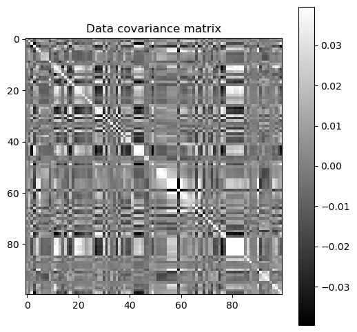

```python
# compute the mean of each data feature
datamean = np.mean(dataMat,axis=0)

# mean-center the data using broadcasting
dataMatM = dataMat - datamean

# confirm that any given feature has mean=0 (or very close...)
print(np.mean(dataMatM[:,0]))


# Now to compute the covariance matrix
covMat = dataMatM.T @ dataMatM  # data matrix times its transpose
covMat /= (dataMatM.shape[0]-1) # divide by N-1

# dynamic color scaling
clim = np.max(np.abs(covMat)) * .2

# and show it
plt.figure(figsize=(6,6))
plt.imshow(covMat,vmin=-clim,vmax=clim,cmap='gray')
plt.colorbar()
plt.title('Data covariance matrix')
plt.savefig('Figure_07_01.png',dpi=300)
plt.show()
```

### Rank of a Matrix

```python
import pandas as pd
import numpy as np

# Sample DataFrame
data = {'col1': [1, 2, 3], 'col2': [4, 5, 6], 'col3': [7, 8, 9]}
df = pd.DataFrame(data)

# Convert DataFrame to NumPy array
matrix = df.values

# Calculate the rank of the matrix
rank = np.linalg.matrix_rank(matrix)

print("Rank of the matrix:", rank)
```

```
Rank of the matrix: 2
```

```python
df.head()
```

|  | col1 | col2 | col3 |
| --- | --- | --- | --- |
| 0 | 1 | 4 | 7 |
| 1 | 2 | 5 | 8 |
| 2 | 3 | 6 | 9 |

```python
df.shape
```

```
(3, 3)
```

```python
df.corr()
```

|  | col1 | col2 | col3 |
| --- | --- | --- | --- |
| col1 | 1.0 | 1.0 | 1.0 |
| col2 | 1.0 | 1.0 | 1.0 |
| col3 | 1.0 | 1.0 | 1.0 |

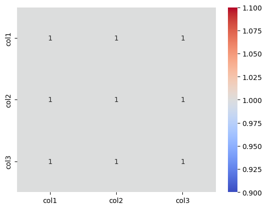

```python
import seaborn as sns
correlation_matrix = df.corr()
sns.heatmap(correlation_matrix, annot=True, cmap='coolwarm')
plt.show()
```

```python
# Sample DataFrame
data = {'col1': [1, 2, 3], 'col2': [3, 2, 1], 'col3': [17, 8, 29]}
df = pd.DataFrame(data)
```

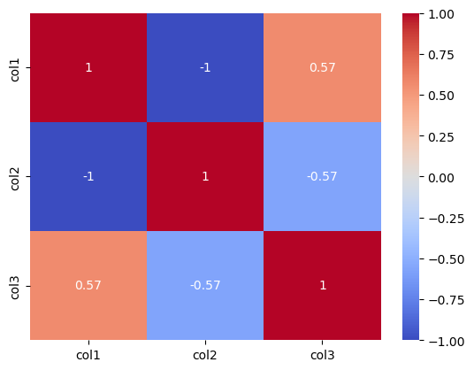

```python
correlation_matrix = df.corr()
sns.heatmap(correlation_matrix, annot=True, cmap='coolwarm')
plt.show()
```